Main Page

# CS170A -- HW#2: Eigenfaces -- Matlab

Your name: Jerry Liu

Your UID: 404474229

**Please upload only this notebook to CCLE by the deadline.**

**Policy for late submission of solutions:** We will use Paul Eggert's Late Policy: $N$ days late $\Leftrightarrow$ $2^N$ points deducted} The number of days late is $N=0$ for the first 24 hrs, $N=1$ for the next 24 hrs, etc., and if you submit an assignment $H$ hours late, $2^{\lfloor \,H\,/\,24\, \rfloor}$ points are deducted.

## Problem 1: Eigenfaces

Chapter 11 of the Course Reader is on Eigenfaces. For this assignment we have included the face files for this chapter in the directory `old_faces`. It includes some Matlab scripts and a database of 177 face images, each a grayscale `.bmp` bitmap file of size $64 \times 64$ pixels. The face images have been pre-processed so that the background and hair are removed and the faces have similar lighting conditions.

The Course Reader explains how to reshape each face image into a $1 \times 64^2 \, = \, 1 \times 4096$ row vector, and collect them into a matrix. The principal components of the matrix then define the main dimensions of variance in the faces. The program `more_efficient_eigenfaces.m` shows how to do this. These principal components are called *eigenfaces*.

### 1a: The Average Face

Modify the program `more_efficient_eigenfaces.m` (available in this directory) to use the `new_faces` images instead of the `old_faces` images. Also, modify it to use the Matlab function `imresize` to downsample each of the new faces by a factor of 3, so it is $64 \times 54$ (instead of $193 \times 162$). Then: *pad* both sides of the image with `zeros(64,5)` so the result is a $64 \times 64$ image.

Then: create a function that takes as input a string array of filenames of face images, an integer $k$, and an integer sample size $s$ --- and yields the average face and the first $k$ singular values and eigenfaces as output values for a sample of size $s$.

Apply your function to both the `new_faces/faces` and the `new_faces/smiling_faces` directories, and plot the absolute value of the difference between your average face and (your downsampled version of) the average face provided in the directory.

(The `imagesc` function can display images with automatic rescaling of numeric values.)

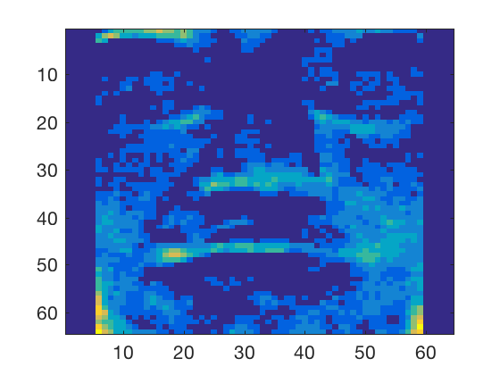

```matlab
row = 64;
col = 64;

%----------------------------------------------------------------------------------
%        Useful functions for converting  images  <-->  vectors
%----------------------------------------------------------------------------------
%
%   These bitmap images are 64x64 matrices of uint8 (unsigned 8-bit) values;
%   we convert these to double values in order to permit arithmetic.
%
%   We also convert 64 x 64 image matrices to 64^2 x 1 vectors (using reshape())
%   so that we can derive eigenfaces using Matlab's SVD/matrix functions.
%
%----------------------------------------------------------------------------------

image_vector = @(Bitmap) double(reshape(Bitmap,1,row*col));

vector_image = @(Vec) reshape( uint8( min(max(Vec,0),255) ), row, col);

vector_render = @(Vec) imshow(vector_image(Vec));

image_resize = @(Bitmap) [zeros(64, 5) imresize(Bitmap, [64 54]) zeros(64, 5)];

samplesize = 150;

%  image showing the difference between your average normal face and the one provided
cd new_faces/faces/
filenames = dir('*.jpg');
file_average_face = 'averagefaceimage_seta.jpeg';

[f0, singular_values, eigen_faces] = eigenface(filenames, 30, 150);

average_a = image_resize(imread(file_average_face));

diff = abs(vector_image(f0) - average_a);

imagesc(diff);

cd ../../
```

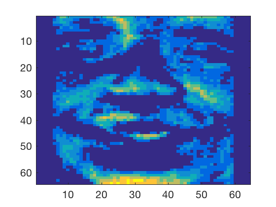

```matlab
%  image showing the difference between your average smiling face and the one provided

samplesize = 150;

cd new_faces/smiling_faces/
filenames = dir('*.jpg');
file_average_face = 'averagefaceimage_setb.jpeg';

[f1, singular_values_smiling, eigen_smiling_faces] = eigenface(filenames, 30, samplesize);

average_b = image_resize(imread(file_average_face));

diff = abs(vector_image(f1) - average_b);

imagesc(diff);

cd ../../
```

### 1b: Smiling makes a Difference

If your mean normal face is $\overline{\mathbf{f}}_0$, and your mean smiling face is $\overline{\mathbf{f}}_1$, render (using `imagesc`) the difference $\overline{\mathbf{f}}_0-\overline{\mathbf{f}}_1$ (the average difference between normal faces and smiling faces).

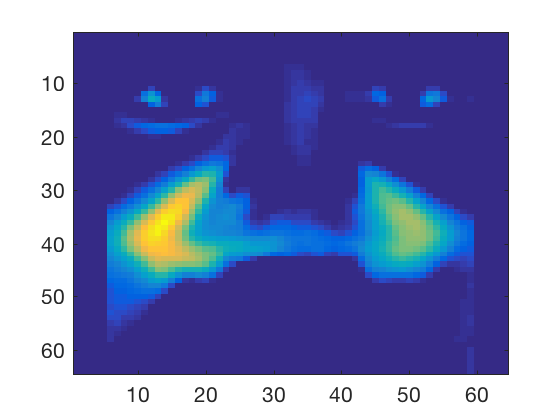

```matlab
%  image showing the difference between the average normal face and average smiling face

smiling_diff = f0 - f1;
imagesc(vector_image(smiling_diff));
```

### 1c: Scree Plots and $k$-Approximation

Using your downsampled images, perform PCA on each set of faces (normal and smiling).

For each image (normal or smiling), construct its $64^2 \times 1$ vector $\mathbf{f}$. Then, subtract the average face ($\overline{\mathbf{f}}_0$ or $\overline{\mathbf{f}}_1$) and project the remainder on the first $k = 60$ eigenfaces. For example, with a smiling face, the projection of $\mathbf{f}$ on the $j$-th smiling eigenface $\mathbf{e}_j$ is $$ c_j ~=~ {(\mathbf{f} \, - \, \overline{\mathbf{f}}_1)}' \, {\mathbf{e}_j} ~~~~~~~~~~ (j = 1,\dots,k). $$

For each set of faces (normal or smiling), make one large scree plot for the set, showing all sequences of the first $k$ coefficients for each image overplotted (e.g. with `hold on`).

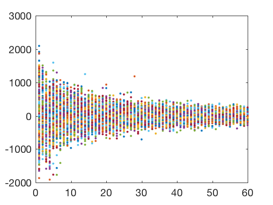

```matlab
%  (overlaid) scree plots for normal faces

row = 64;
col = 64;

cd new_faces/faces/
filenames = dir('*.jpg');
filesize = size(filenames, 1);

F_norm = zeros(samplesize, row * col); % the array of sample images (stored as vectors)

%numfiles = size(filenames,1);
%rp = randperm(numfiles);       %  random permutation of the list of image filenames

%sample = rp(1:samplesize);     %  use the first <samplesize> images as our sample

image_resize = @(Bitmap) [zeros(64, 5) imresize(Bitmap, [64 54]) zeros(64, 5)];

for i = 1 : filesize
   Image_File = filenames(i).name;
   Face_Matrix = image_resize(imread(Image_File));
   F_norm(i,:) = image_vector(Face_Matrix);  % the i-th row of F is the i-th image
end

f0 = sum(F_norm,1) / filesize;

%----------------------------------------------------------------------------------
%        Subtract the average face from each face in F
%----------------------------------------------------------------------------------

for i = 1 : filesize
   F_norm(i,:) = F_norm(i,:) - f0;
end

%----------------------------------------------------------------------------------
%       Obtain the eigenfaces U with PCA
%----------------------------------------------------------------------------------

%%%%%%%%%%%%%%%%%%%%%%%%%%%%%%%%%%%%  [U, S, V] = svds( cov(F), k);  %%%% expensive
%%%%%%%%%%%%%%%%%%%%%%%%%%%%%%%%%%%%  singular_values = diag(S);

% do these things more efficiently:

k = 60;

[eigen_faces_60, singular_values_60] = more_efficient_pca( F_norm, k );

%----------------------------------------------------------------------------------
%   The columns of the U matrix obtained with PCA are our "eigenfaces".
%
%   That is, e_1, e_2, ..., e_k are the first k eigenfaces:
%
%          U  =  ( e_1 | e_2 | ... | e_k | ... )
%
%   These eigenfaces are orthonormal, and define our axes of "face space".
%
%----------------------------------------------------------------------------------

%----------------------------------------------------------------------------------
%   Finding the eigenface representation of a face
%----------------------------------------------------------------------------------
%
%   Any face image (here, a row vector) f can be represented as a sum
%
%       f  =  fbar   +   c_1 * e_1' +  c_2 * e_2'  +  ...  +  c_k * e_k'
%
%   where the c_j's are the  "coordinates in face space"  for f, or equivalently,
%   if  c  = [c_1; c_2; ...; c_k; 0; ...; 0]  is a row vector of coefficients then
%
%       f  =  fbar   +   c * U'.
%
%   Thus an image f (a 64 x 64 array) is represented by a vector c
%   containing only k numbers.   Impressive compression!
%
%----------------------------------------------------------------------------------

% t = f - fbar;    %  remove the average face before finding eigencoefficients

% c = t * U;      %  eigencoefficients for f:    c_j  =  t * e_j

% c: 1 x k

C_norm = zeros(filesize, k);

figure
for i = 1 : filesize
   C_norm(i, :) = F_norm(i,:) * eigen_faces_60;
   plot(C_norm(i, 1 : k), '.');
   hold on;
end

cd ../../
```

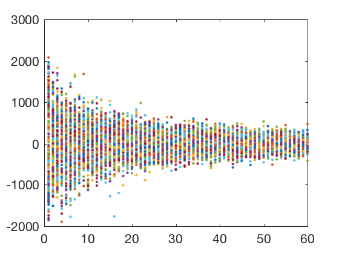

```matlab
%  (overlaid) scree plots for smiling faces

row = 64;
col = 64;

cd new_faces/smiling_faces/
filenames = dir('*.jpg');
filesize = size(filenames, 1);

F_smiling = zeros(samplesize, row * col); % the array of sample images (stored as vectors)

%numfiles = size(filenames,1);
%rp = randperm(numfiles);       %  random permutation of the list of image filenames

%sample = rp(1:samplesize);     %  use the first <samplesize> images as our sample

image_resize = @(Bitmap) [zeros(64, 5) imresize(Bitmap, [64 54]) zeros(64, 5)];

for i = 1 : filesize
   Image_File = filenames(i).name;
   Face_Matrix = image_resize(imread(Image_File));
   F_smiling(i,:) = image_vector(Face_Matrix);  % the i-th row of F is the i-th image
end

f1 = sum(F_smiling,1) / filesize;

%----------------------------------------------------------------------------------
%        Subtract the average face from each face in F
%----------------------------------------------------------------------------------

for i = 1 : filesize
   F_smiling(i,:) = F_smiling(i,:) - f1;
end

%----------------------------------------------------------------------------------
%       Obtain the eigenfaces U with PCA
%----------------------------------------------------------------------------------

%%%%%%%%%%%%%%%%%%%%%%%%%%%%%%%%%%%%  [U, S, V] = svds( cov(F), k);  %%%% expensive
%%%%%%%%%%%%%%%%%%%%%%%%%%%%%%%%%%%%  singular_values = diag(S);

% do these things more efficiently:

k = 60;

[eigen_smiling_faces_60, singular_values_smiling_60] = more_efficient_pca( F_smiling, k );

%----------------------------------------------------------------------------------
%   The columns of the U matrix obtained with PCA are our "eigenfaces".
%
%   That is, e_1, e_2, ..., e_k are the first k eigenfaces:
%
%          U  =  ( e_1 | e_2 | ... | e_k | ... )
%
%   These eigenfaces are orthonormal, and define our axes of "face space".
%
%----------------------------------------------------------------------------------

%----------------------------------------------------------------------------------
%   Finding the eigenface representation of a face
%----------------------------------------------------------------------------------
%
%   Any face image (here, a row vector) f can be represented as a sum
%
%       f  =  fbar   +   c_1 * e_1' +  c_2 * e_2'  +  ...  +  c_k * e_k'
%
%   where the c_j's are the  "coordinates in face space"  for f, or equivalently,
%   if  c  = [c_1; c_2; ...; c_k; 0; ...; 0]  is a row vector of coefficients then
%
%       f  =  fbar   +   c * U'.
%
%   Thus an image f (a 64 x 64 array) is represented by a vector c
%   containing only k numbers.   Impressive compression!
%
%----------------------------------------------------------------------------------

% t = f - fbar;    %  remove the average face before finding eigencoefficients

% c = t * U;      %  eigencoefficients for f:    c_j  =  t * e_j

% c: 1 x k

C_smiling = zeros(filesize, k);

figure
for i = 1 : filesize
   C_smiling(i, :) = F_smiling(i,:) * eigen_smiling_faces_60;
   plot(C_smiling(i, :), '.');
   hold on;
end

cd ../../
```

### 1d: Unusualness of a Face

Let us say the *unusualness* of a face is the $L_2$ norm of its eigenface-coefficient vector (using the first $k=60$ eigenfaces).

Determine, for each set (normal or smiling), the most unusual face.

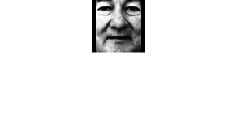

```matlab
%  the most unusual normal face

%L2Norm = zeros(filesize, 1);
%for i = 1 : samplesize
%    L2Norm(i) = norm(C_norm(i, :));
%end

L2Norm = sqrt(sum(C_norm .^ 2, 2));
[maxSum unusualNormalIndex] = max(L2Norm);
% unusualNormalIndex
most_unusual_normal_face = F_norm(unusualNormalIndex, :) + f0;
figure
vector_render(most_unusual_normal_face);
```

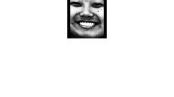

```matlab
%  the most unusual smiling face

%L2Norm = zeros(samplesize, 1);
%for i = 1 : samplesize
%    L2Norm(i) = norm(C_smiling(i, :));
%end

L2Norm = sqrt(sum(C_smiling .^ 2, 2));
[maxSum unusualSmilingIndex] = max(L2Norm);
% unusualSmilingIndex
most_unusual_smiling_face = F_smiling(unusualSmilingIndex, :) + f1;
figure
vector_render(most_unusual_smiling_face);
```

## Problem 2: Face Classifiers

Develop two different face classifiers using the eigenfaces you've computed; each should be a function that, given a face image $\mathbf{f}$ as input, yields the output value 1 if $\mathbf{f}$ is smiling, and 0 otherwise. (NOTE: or vice-versa; we just need the function to be a classifier)

- {Classifier X}: yield 1 if the normal face unusualness of $\mathbf{f}$ is greater than smiling face unusualness of $\mathbf{f}$, else 0.
- {Classifier Y}: yield 1 if $||{\mathbf{f} - \overline{\mathbf{f}}_0}||^2 ~\geq ~ ||{\mathbf{f} - \overline{\mathbf{f}}_1}||^2$, else 0.

### 2a: Unusual Face Classification

Using each of these classifiers, determine the classification it yields for the two most unusual images you found in the previous question.

```matlab
%  X, Y classifications of the most unusual normal face

classifierX = @(ivec, f0, f1) norm((ivec - f0) * eigen_faces_60) > norm((ivec - f1) * eigen_smiling_faces_60);

classifierX(most_unusual_normal_face, f0, f1)

classifierY = @(ivec, f0, f1) norm((ivec - f0), 1)^2 >= norm((ivec - f1), 1)^2;

classifierY(most_unusual_normal_face, f0, f1)
```

```
ans =

  logical

   1


ans =

  logical

   1
```

```matlab
%  X, Y classifications of the most unusual smiling face

classifierX = @(ivec, f0, f1) norm((ivec - f0) * eigen_faces_60) > norm((ivec - f1) * eigen_smiling_faces_60);

classifierX(most_unusual_smiling_face, f0, f1)

classifierY = @(ivec, f0, f1) norm((ivec - f0), 1)^2 >= norm((ivec - f1), 1)^2;

classifierY(most_unusual_smiling_face, f0, f1)
```

```
ans =

  logical

   0


ans =

  logical

   1
```

### 2b: Splitting into Training and Test sets

Write a function `[Sublist1 Sublist2] = randsplit(List)` that takes an array `List` of length `n` and splits it randomly into two sublists of size `floor(n/2)` and `ceil(n/2)`. (Hint: `randperm`)

Use `randsplit` to split each of the 200-face sets into a training subset and testing subset of equal size.

For both sets of faces (100 normal faces and 100 smiling faces), compute the average normal and smiling faces $\overline{\mathbf{f}}_0$ and $\overline{\mathbf{f}}_1$ for the training set.

```matlab
% The randsplit function

function [Sublist1, Sublist2] = randsplit(List)
    n = size(List, 1);
    IndexArr = randperm(n);
    n_floor = int32(floor(n / 2));
    Sublist1 = zeros(n_floor, 1);
    for i = 1 : n_floor
        Sublist1(i) = List(IndexArr(i));
    end

    n_ceil = int32(ceil(n / 2));
    Sublist2 = zeros(n_ceil, 1);
    for i = 1 : n_ceil
        Sublist2(i) = List(IndexArr(i + n_floor));
    end
end
```

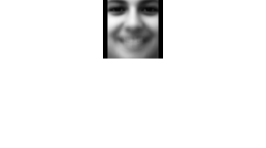

```matlab
% The average smiling face (for the training set)

samplesize = 200;
k = 60;

cd new_faces/smiling_faces/
filenames = dir('*.jpg');

index = linspace(1, samplesize, samplesize)';

[TrainingIndex, TestingIndex] = randsplit(index);

trainingSize = size(TrainingIndex, 1);

TrainingSmiling = filenames(1 : trainingSize);

for i = 1 : trainingSize
    TrainingSmiling(i) = filenames(i);
end

testingSize = size(TestingIndex, 1);

TestingSmiling = filenames(1 : testingSize);
for i = 1 : testingSize
    TestingSmiling(i) = filenames(i);
end

[f1bar, singular_values, eigen_smiling_faces_60] = eigenface(TrainingSmiling, k, trainingSize);

figure
vector_render(f1bar);

cd ../../
```

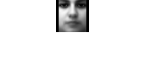

```matlab
% The average normal face (for the training set)

samplesize = 200;
k = 60;

cd new_faces/faces/
filenames = dir('*.jpg');

index = linspace(1, samplesize, samplesize)';

[TrainingIndex, TestingIndex] = randsplit(index);

trainingSize = size(TrainingIndex, 1);

TrainingNormal = filenames(1 : trainingSize);

for i = 1 : trainingSize
    TrainingNormal(i) = filenames(i);
end

testingSize = size(TestingIndex, 1);

TestingNormal = filenames(1 : testingSize);
for i = 1 : testingSize
    TestingNormal(i) = filenames(i);
end

[f0bar, singular_values, eigen_faces_60] = eigenface(TrainingNormal, k, trainingSize);

figure
vector_render(f0bar);

cd ../../
```

### 2c: Classifier Error Rate

Then rank the classifiers by their error rate.

#### For normal faces (using the test set):

```matlab
% X, Y error rates

cd new_faces/faces/

for i = 1 : testingSize
   Image_File = TestingNormal(i).name;
   Face_Matrix = image_resize(imread(Image_File));
   F_norm(i,:) = image_vector(Face_Matrix);  % the i-th row of F is the i-th image
end

results = zeros(testingSize, 1);
for i = 1 : testingSize
    results(i) = classifierX(F_norm(i, :), f0bar, f1bar);
end

error_rates_X_norm = sum(results) / testingSize

results = zeros(testingSize, 1);
for i = 1 : testingSize
    results(i) = classifierY(F_norm(i, :), f0bar, f1bar);
end

error_rates_Y_norm = sum(results) / testingSize

cd ../../
```

```
error_rates_X_norm =

    0.1000


error_rates_Y_norm =

    0.0500
```

```matlab
%  which of the classifiers has lowest error rate for normal faces in the test set?

%  Classifier Y
```

#### For smiling faces (using the test set):

```matlab
% X, Y error rates

cd new_faces/smiling_faces/

for i = 1 : testingSize
   Image_File = TestingSmiling(i).name;
   Face_Matrix = image_resize(imread(Image_File));
   F_smiling(i,:) = image_vector(Face_Matrix);  % the i-th row of F is the i-th image
end

results = zeros(testingSize, 1);
for i = 1 : testingSize
    results(i) = classifierX(F_smiling(i, :), f0bar, f1bar);
end

error_rates_X_norm = sum(~results) / testingSize

results = zeros(testingSize, 1);
for i = 1 : testingSize
    results(i) = classifierY(F_smiling(i, :), f0bar, f1bar);
end

error_rates_Y_norm = sum(~results) / testingSize

cd ../../
```

```
error_rates_X_norm =

    0.3200


error_rates_Y_norm =

    0.1400
```

```matlab
%  which of the classifiers has lowest error rate for smiling faces in the test set?

% Classifier Y
```

## Problem 3: Face Compression

In the previous problem you computed the first 60 Eigenface coefficients, and used these to find the most unusual face.

For each $64 \times 64$ image $X$ from your (downsampled) smiling faces, compute the following sequences:

- (descendingly sorted absolute values of) the first 60 Eigenface coefficients for $X$
- (descendingly sorted absolute values of) the first 60 coefficient values from the two-sided FFT of $X$ (in Matlab: `fft2(X)`)
- (descendingly sorted absolute values of) the first 60 coefficient values from the two-sided DCT of $X$ (in Matlab: `dct2(X)`)
- the first 60 singular values from the SVD of $X$.

We get an *image compression* scheme if we keep only the first $k \leq 60$ coefficients, and discard the rest.

Define $$ \mbox{$k$-coefficient compression error} ~~=~~ \frac{\mbox{(the sum of absolute values of all coefficients after the first $k$)}}{\mbox{(the sum of absolute values of all coefficients)}} . $$

Compute the $k$-coefficient compression error for each of the 4 transforms, $1 \leq k \leq 60$, for the smiling test set.

Rank the 4 transforms above by their average compression error (for $k \leq 60$).

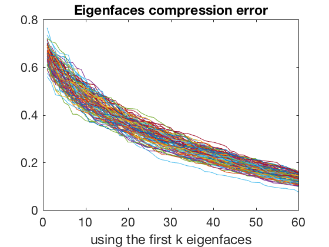

```matlab
%  plot of the Eigenface's k-coefficient compression error   (for k <= 60)

%----------------------------------------------------------------------------------
%       Obtain the eigenfaces U with PCA
%----------------------------------------------------------------------------------

%%%%%%%%%%%%%%%%%%%%%%%%%%%%%%%%%%%%  [U, S, V] = svds( cov(F), k);  %%%% expensive
%%%%%%%%%%%%%%%%%%%%%%%%%%%%%%%%%%%%  singular_values = diag(S);

% do these things more efficiently:

k = 60;
[eigen_smiling_faces_sample, singular_values_smiling_sample] = more_efficient_pca( F_smiling, testingSize );
C_smiling = zeros(testingSize, testingSize);
for i = 1 : testingSize
    C_smiling(i, :) = F_smiling(i,:) * eigen_smiling_faces_sample;
end

k_coeff_comp_error_eigen = zeros(testingSize , k);

for i = 1 : testingSize
    for j = 1 : k
        % (the sum of absolute values of all coefficients after the first k) /
        % (the sum of absolute values of all coefficients)
        k_coeff_comp_error_eigen(i, j) = sum(abs(C_smiling(i, j + 1 : testingSize))) / sum(abs(C_smiling(i, 1 : testingSize)));
    end
end

figure
plot(1 : k, k_coeff_comp_error_eigen);
title('Eigenfaces compression error')
xlabel('using the first k eigenfaces')
```

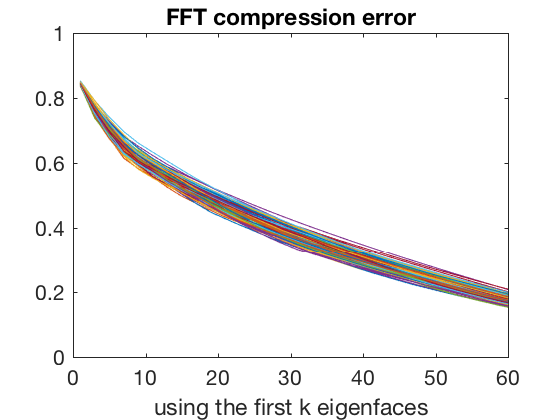

```matlab
%  plot of the two-sided FFT's k-coefficient compression error  (for k <= 60)

%%%   You might do something like this:
%   TwoSidedFFTofX = fft2(X);
%   SortedAbsoluteValuesOfFourierCoefficients = sort(abs(TwoSidedFFTofX(:)), 'descend');
%   figure
%   plot( SortedAbsoluteValuesOfFourierCoefficients(1:60) )

k = 60;
C_smiling = zeros(testingSize, 4096);
for i = 1 : testingSize
    C_smiling(i, :) = sort(abs(fft2(F_smiling(i, :))), 'descend');
end

k_coeff_comp_error_fft = zeros(testingSize , k);

for i = 1 : testingSize
    for j = 1 : k
        % (the sum of absolute values of all coefficients after the first k) /
        % (the sum of absolute values of all coefficients)
        k_coeff_comp_error_fft(i, j) = sum(abs(C_smiling(i, j + 1 : testingSize))) / sum(abs(C_smiling(i, 1 : testingSize)));
    end
end

figure
plot(1 : k, k_coeff_comp_error_fft);
title('FFT compression error')
xlabel('using the first k eigenfaces')
```

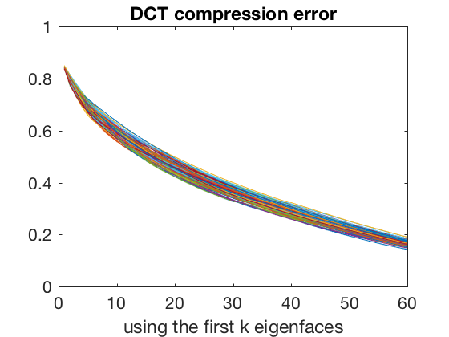

```matlab
%  plot of the two-sided DCT's k-coefficient compression error  (for k <= 60)

k = 60;
C_smiling = zeros(testingSize, 4096);
for i = 1 : testingSize
    C_smiling(i, :) = sort(abs(dct2(F_smiling(i, :))), 'descend');
end

k_coeff_comp_error_dct = zeros(testingSize , k);

for i = 1 : testingSize
    for j = 1 : k
        % (the sum of absolute values of all coefficients after the first k) /
        % (the sum of absolute values of all coefficients)
        k_coeff_comp_error_dct(i, j) = sum(abs(C_smiling(i, j + 1 : testingSize))) / sum(abs(C_smiling(i, 1 : testingSize)));
    end
end

figure
plot(1 : k, k_coeff_comp_error_dct);
title('DCT compression error')
xlabel('using the first k eigenfaces')
```

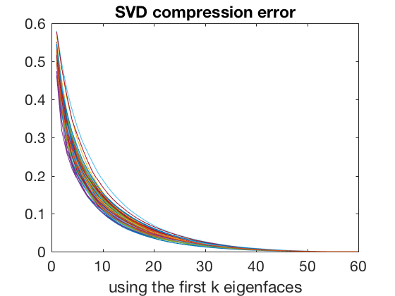

```matlab
%  plot of the rank-k singular value compression error (for k <= 60)

k = 60;
col = 64;
C_smiling = zeros(testingSize, col);
for i = 1 : testingSize
    [U, S, V] = svd(double(vector_image(F_smiling(i,:))));
    C_smiling(i, :) = diag(S);
end

k_coeff_comp_error_svd = zeros(testingSize , k);

for i = 1 : testingSize
    for j = 1 : k
        % (the sum of absolute values of all coefficients after the first k) /
        % (the sum of absolute values of all coefficients)
        k_coeff_comp_error_svd(i, j) = sum(abs(C_smiling(i, j + 1 : col))) / sum(abs(C_smiling(i, 1 : col)));
    end
end

figure
plot(1 : k, k_coeff_comp_error_svd);
title('SVD compression error')
xlabel('using the first k eigenfaces')
```

```matlab
%  which of the 4 compression schemes has lowest average compression error?

[val index] = min([mean(k_coeff_comp_error_eigen); mean(k_coeff_comp_error_fft); mean(k_coeff_comp_error_dct); mean(k_coeff_comp_error_svd)]);
if index == 1
    fprintf('Eigenfaces');
elseif index == 2
    fprintf('FFT');
elseif index == 3
    fprintf('DCT');
else
    fprintf('SVD');
end
fprintf(' has the smallest average compression error');
```

```
SVD has the smallest average compression error
```